# Reproducible Research: Peer Assessment 1

James Francisco

September 9, 2018

### Objective

The objective of this assignment is to answer a series of questions using data collected from a [FitBit](http://en.wikipedia.org/wiki/Fitbit).

### Loading Libraries and the data to be analyzed

```r
library("knitr")
library("markdown")
library("ggplot2")
library("plyr")
library(lattice)
movement <- read.csv("C:\\Users\\james\\OneDrive\\Documents\\Coursera\\Reproducible Research\\RepData_PeerAssessment1\\activity\\activity.csv")
```

### Cleaning data to removed missing values.

```r
clean <- movement[!is.na(movement$steps),]
movement$day <- weekdays(as.Date(movement$date))
movement$DateTime<- as.POSIXct(movement$date, format="%Y-%m-%d")
sumTable <- aggregate(movement$steps ~ movement$date, FUN=sum )
colnames(sumTable)<- c("Date", "Steps")
```

### Create the historgram of total steps per day

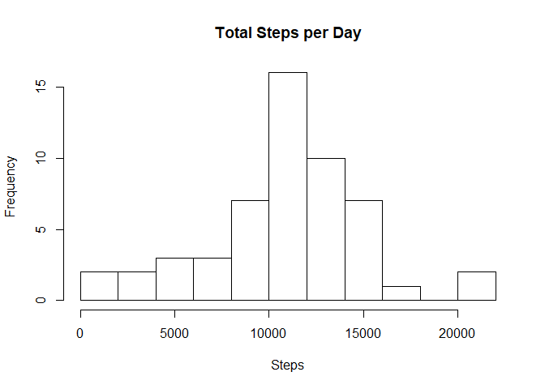

```r
hist(sumTable$Steps, breaks=10, xlab="Steps", main = "Total Steps per Day")
```

### What are the mean and median total number of steps taken per day?

```r
movemean<-as.integer(mean(sumTable$Steps))
movemedian<-as.integer(median(sumTable$Steps))
```

The average total number of steps is 10766 and the median is 10765.

### What is the average daily activity pattern?

#### Create average number of steps per interval

```r
intervalTable <- ddply(clean, .(interval), summarize, Avg = mean(steps))
```

#### Create line plot of average number of steps per interval

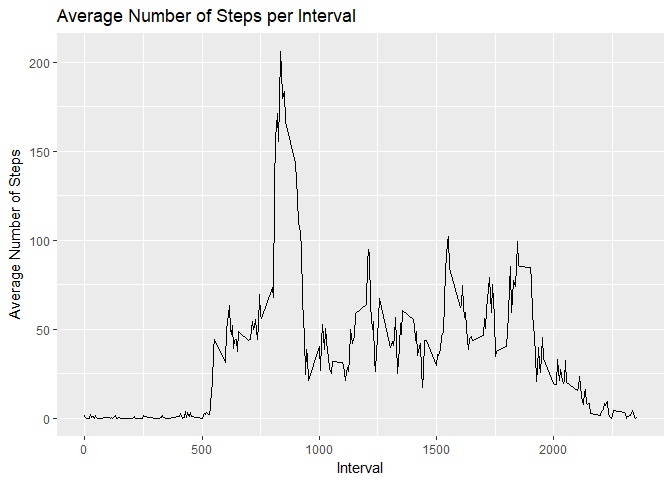

```r
p <- ggplot(intervalTable, aes(x=interval, y=Avg), xlab = "Interval", ylab="Average Number of Steps")
p + geom_line()+xlab("Interval")+ylab("Average Number of Steps")+ggtitle("Average Number of Steps per Interval")
```

```r
##Maximum steps by interval
maxSteps <- max(intervalTable$Avg)
##Which interval contains the maximum average number of steps
intervalTable[intervalTable$Avg==maxSteps,1]
```

```
## [1] 835
```

The maximum number of steps for a 5-minute interval was 206.1698113 steps.

The 5-minute interval which had the maximum number of steps was the 835 interval.